# Time Series

João Neto

October 2014

Refs:

- http://a-little-book-of-r-for-time-series.readthedocs.org/en/latest/src/timeseries.html
- http://www.statoek.wiso.uni-goettingen.de/veranstaltungen/zeitreihen/sommer03/ts_r_intro.pdf
- Also check packages: zoo, [xts](http://cran.r-project.org/web/packages/xts/vignettes/xts.pdf) and [Quandl](https://www.quandl.com/help/r).

## Introduction

Time series are different than usual dataseries because there usually contain periodic patterns (weekly, yearly…). To find these patterns its needed different types of analysis, since instead of assuming the sequence of observations does not matter, we are assuming that it matters, old observations help predict new ones.

Time series $X_t$ usually have two or three components

- Trend component $T_t$
- Seasonal component $S_t$
- Irregular or residual component $e_t$

A time series with seasonal component is called seasoned data (eg, sales per month). Some data series does not have a seasonal component (eg, a population mortality average).

R has a class time series named `ts`:

```r
my.data <- round( sin( (0:47 %% 12)+1 ) + runif(48)  ,1) # some periodic data
# make a time series with 48 observations from January 2009 to December 2014
my.ts <- ts(my.data, start=c(2009, 1), end=c(2014, 12), frequency=12)
my.ts
```

```
##       Jan  Feb  Mar  Apr  May  Jun  Jul  Aug  Sep  Oct  Nov  Dec
## 2009  1.7  1.7  0.3 -0.8 -0.9 -0.2  1.2  1.8  1.4  0.1 -0.2 -0.4
## 2010  0.9  1.9  0.8 -0.6 -0.2  0.0  0.7  1.0  1.3 -0.2 -0.9  0.3
## 2011  1.7  1.5  0.7  0.2 -0.9 -0.1  1.4  1.7  0.7 -0.2 -0.3 -0.5
## 2012  1.0  1.1  1.1  0.1 -0.4  0.6  1.6  1.9  1.4  0.2 -0.6 -0.5
## 2013  1.7  1.7  0.3 -0.8 -0.9 -0.2  1.2  1.8  1.4  0.1 -0.2 -0.4
## 2014  0.9  1.9  0.8 -0.6 -0.2  0.0  0.7  1.0  1.3 -0.2 -0.9  0.3
```

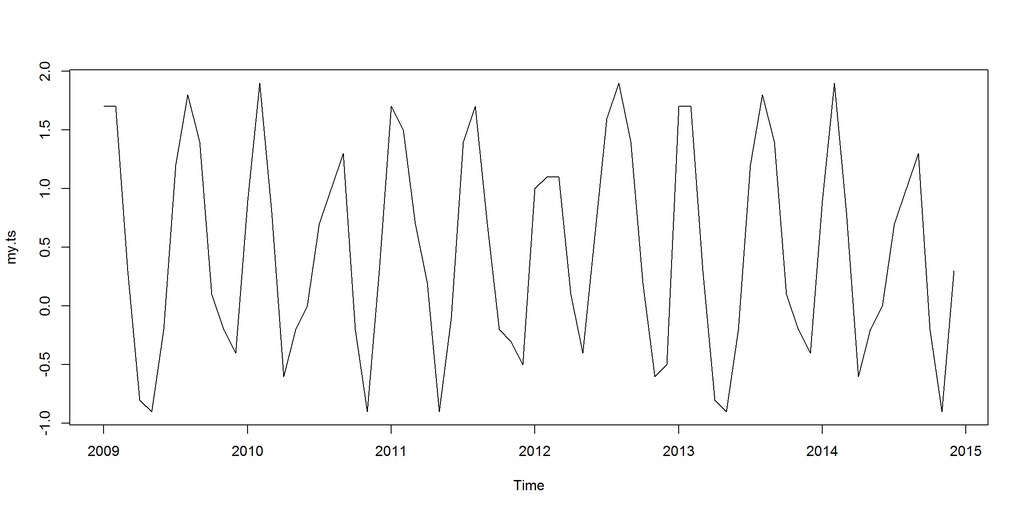

```r
plot(my.ts)
```

```r
ts(my.data, end=c(2009,1), frequency=4) # ts is smart and go back in time if we just give the 'end' parameter
```

```
##      Qtr1 Qtr2 Qtr3 Qtr4
## 1997       1.7  1.7  0.3
## 1998 -0.8 -0.9 -0.2  1.2
## 1999  1.8  1.4  0.1 -0.2
## 2000 -0.4  0.9  1.9  0.8
## 2001 -0.6 -0.2  0.0  0.7
## 2002  1.0  1.3 -0.2 -0.9
## 2003  0.3  1.7  1.5  0.7
## 2004  0.2 -0.9 -0.1  1.4
## 2005  1.7  0.7 -0.2 -0.3
## 2006 -0.5  1.0  1.1  1.1
## 2007  0.1 -0.4  0.6  1.6
## 2008  1.9  1.4  0.2 -0.6
## 2009 -0.5
```

`window` makes a subset of a timeseries:

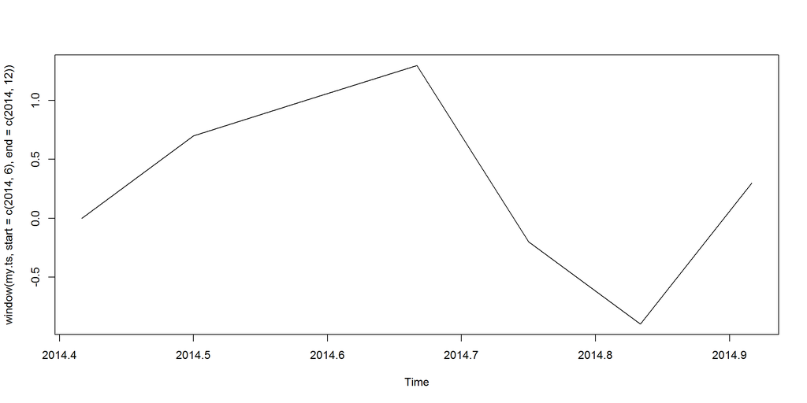

```r
plot( window(my.ts, start=c(2014, 6), end=c(2014, 12)) )
```

Other operations:

```r
time(my.ts)                # creates the vector of times at which a time series was sampled.
```

```
##       Jan  Feb  Mar  Apr  May  Jun  Jul  Aug  Sep  Oct  Nov  Dec
## 2009 2009 2009 2009 2009 2009 2009 2010 2010 2010 2010 2010 2010
## 2010 2010 2010 2010 2010 2010 2010 2010 2011 2011 2011 2011 2011
## 2011 2011 2011 2011 2011 2011 2011 2012 2012 2012 2012 2012 2012
## 2012 2012 2012 2012 2012 2012 2012 2012 2013 2013 2013 2013 2013
## 2013 2013 2013 2013 2013 2013 2013 2014 2014 2014 2014 2014 2014
## 2014 2014 2014 2014 2014 2014 2014 2014 2015 2015 2015 2015 2015
```

```r
cycle(my.ts)               # gives the positions in the cycle of each observation.
```

```
##      Jan Feb Mar Apr May Jun Jul Aug Sep Oct Nov Dec
## 2009   1   2   3   4   5   6   7   8   9  10  11  12
## 2010   1   2   3   4   5   6   7   8   9  10  11  12
## 2011   1   2   3   4   5   6   7   8   9  10  11  12
## 2012   1   2   3   4   5   6   7   8   9  10  11  12
## 2013   1   2   3   4   5   6   7   8   9  10  11  12
## 2014   1   2   3   4   5   6   7   8   9  10  11  12
```

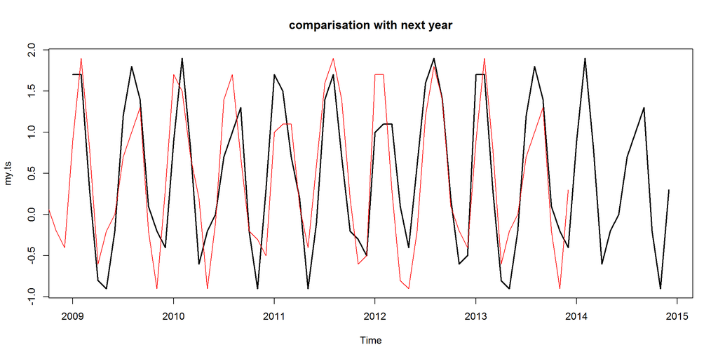

```r
ts1 <- lag(my.ts, k=12)    # lagged version of time series, shifted back k observations
plot(my.ts, , lwd=2, main="comparisation with next year")
points(ts1, type="l", col="red")
```

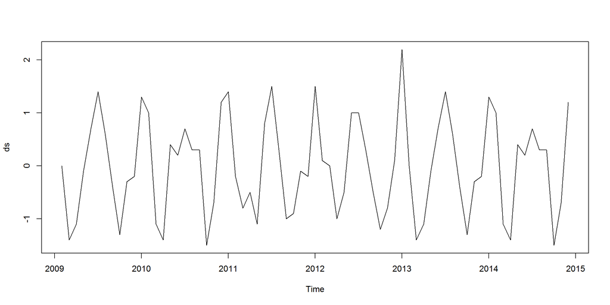

```r
ds <- diff(my.ts, d=1)     # difference vector the time series, d times
plot( ds )
```